# Genetic algorithm

Elizabeth King

Kevin Middleton

## Sampling for parameter estimation

Many problems are more easily (or possibly) solved without a traditional likelihood

1. Sample from distributions and compare to observed values (Approximate Bayesian Computation)
2. Generate “populations” of parameters and let them “evolve” across generations (Genetic Algorithm)

## Genetic algorithm

- “Genetic” in name only
  - Inspired by ideas from evolution: populations, selection, mutation, crossover
- General optimization approach
  - “Stochastic search algorithm” (Scrucca 2013)
  - No likelihood necessary: optimize on MSE, MAE, *r*

## Genetic algorithm history

- Introduced / synthesized: (Holland 1975; Goldberg 1989)
- Modern implementation with derivatives: (Sekhon and Mebane 1998; Mebane and Sekhon 2011)

## Benefits

- General solution for optimization
- Resists getting stuck in local optima
- Can be fast, even for large datasets

## GA schematic

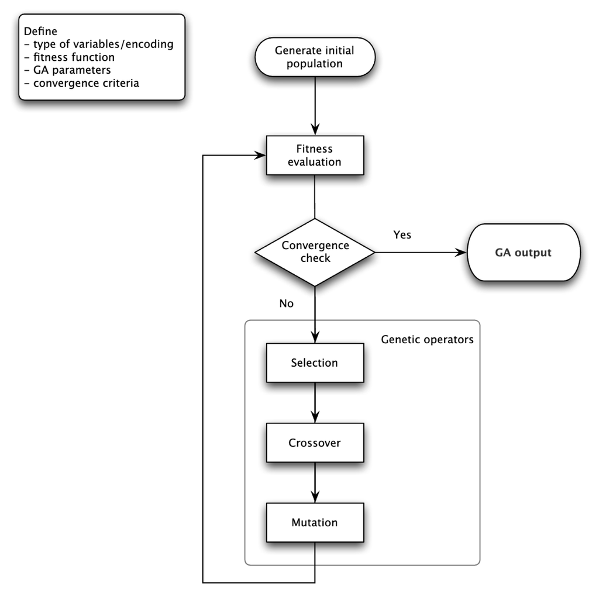

## R packages for GA

1. `rgenoud` (GENetic Optimization Using Derivatives) (Sekhon and Mebane 1998)
   - Combines derivative-based optimization with an evolutionary algorithm
2. `GA` (Scrucca 2013, 2017)

## Simulate data: Gamma(3, 3)

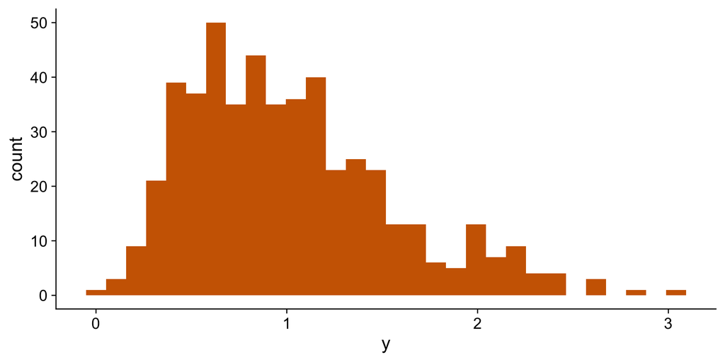

## Model statement and function

$$y \sim Gamma(shape,~rate)$$

```r
gamma_sim <- function(p) {
  log_lik <- sum(dgamma(y, p[1], p[2], log = TRUE))
  return(log_lik)
}

gamma_sim(c(3, 3))
```

```
[1] -357.1765
```

## Choosing the parameter “search” space

- What are the likely values for the parameters?
  - What limits?
- Options to strictly stay in the bounds or allow broader search

## `genoud()` options: `P1` - `P9`

1. Cloning
2. Uniform mutation
3. Boundary mutation
4. Non-uniform mutation
5. Polytope crossover
6. Simple crossover
7. Whole non-uniform mutation
8. Heuristic crossover
9. Local-minimum crossover

## Fitting the model

```r
fm <- genoud(gamma_sim,
             nvars = 2,
             max = TRUE,
             Domains = matrix(c(0, 10,
                                0, 10), nrow = 2, byrow = TRUE),
             pop.size = 5000)
```

## Fitting the model

```
Sat Apr 29 07:29:35 2023
Domains:
 0.000000e+00   <=  X1   <=    1.000000e+01
 0.000000e+00   <=  X2   <=    1.000000e+01

Data Type: Floating Point
Operators (code number, name, population)
    (1) Cloning...........................  622
    (2) Uniform Mutation..................  625
    (3) Boundary Mutation.................  625
    (4) Non-Uniform Mutation..............  625
    (5) Polytope Crossover................  625
    (6) Simple Crossover..................  626
    (7) Whole Non-Uniform Mutation........  625
    (8) Heuristic Crossover...............  626
    (9) Local-Minimum Crossover...........  0

HARD Maximum Number of Generations: 100
Maximum Nonchanging Generations: 10
Population size       : 5000
Convergence Tolerance: 1.000000e-03

Using the BFGS Derivative Based Optimizer on the Best Individual Each Generation.
Checking Gradients before Stopping.
Using Out of Bounds Individuals.

Maximization Problem.
GENERATION: 0 (initializing the population)
Fitness value... -3.544008e+02
mean............ -1.719982e+03
variance........ 4.509387e+06
#unique......... 5000, #Total UniqueCount: 5000
var 1:
best............ 3.526263e+00
mean............ 4.939804e+00
variance........ 8.583669e+00
var 2:
best............ 3.483590e+00
mean............ 5.002956e+00
variance........ 8.164967e+00
```

[output cut: 169 more lines]

```
'wait.generations' limit reached.
No significant improvement in 10 generations.

Solution Fitness Value: -3.543498e+02

Parameters at the Solution (parameter, gradient):

 X[ 1] :    3.461000e+00    G[ 1] : 8.859561e-06
 X[ 2] :    3.412846e+00    G[ 2] : 1.530785e-05

Solution Found Generation 1
Number of Generations Run 12

Sat Apr 29 07:29:39 2023
Total run time : 0 hours 0 minutes and 4 seconds
```

## Differences from ABC

- No prior distributions to draw from
- No samples to process
  - Optima only

## Challenging models

- “Intractable” likelihoods
  - Flat or oddly shaped surfaces
  - Discontinuous likelihood
- Nonlinear models
- Multiple optima

## Non-linear model: Gompertz growth equation

$$y(t) = a e^{-b e^{-c t}}$$

- *a* is the asymptotic size
- *b* is the $x$ displacement of the entire curve
- *c* is growth rate

```r
Gompertz <- function(t, a, b, c) {
  a * exp(-b * exp(-c * t))
}
```

## Simulate data: a = 5, b = 1, c = 0.5

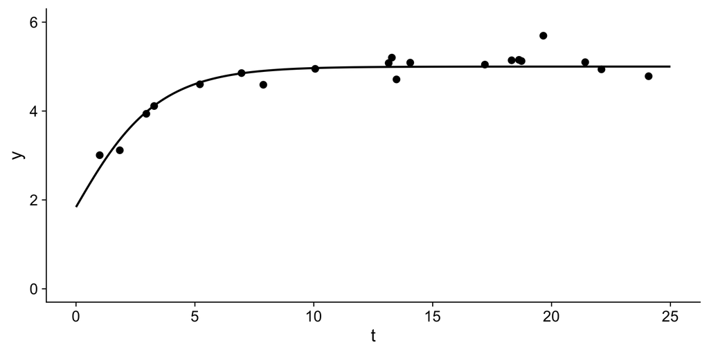

## Fitting the model

```r
Gomp_MSE <- function(p, GGsim) {
  pred <- Gompertz(GGsim$t, p[1], p[2], p[3])
  obs <- GGsim$y
  return(sqrt(mean((obs - pred) ^ 2)))
}

gen <- genoud(fn = Gomp_MSE,
              GGsim = GGsim,
              nvars = 3,
              pop.size = 5000)
```

## Fitting the model

```
Sat Apr 29 07:29:40 2023
Domains:
 -1.000000e+01   <=  X1   <=    1.000000e+01
 -1.000000e+01   <=  X2   <=    1.000000e+01
 -1.000000e+01   <=  X3   <=    1.000000e+01

Data Type: Floating Point
Operators (code number, name, population)
    (1) Cloning...........................  622
    (2) Uniform Mutation..................  625
    (3) Boundary Mutation.................  625
    (4) Non-Uniform Mutation..............  625
    (5) Polytope Crossover................  625
    (6) Simple Crossover..................  626
    (7) Whole Non-Uniform Mutation........  625
    (8) Heuristic Crossover...............  626
    (9) Local-Minimum Crossover...........  0

HARD Maximum Number of Generations: 100
Maximum Nonchanging Generations: 10
Population size       : 5000
Convergence Tolerance: 1.000000e-03

Using the BFGS Derivative Based Optimizer on the Best Individual Each Generation.
Checking Gradients before Stopping.
Using Out of Bounds Individuals.

Minimization Problem.
GENERATION: 0 (initializing the population)
Fitness value... 4.474752e-01
mean............ inf
variance........ inf
#unique......... 5000, #Total UniqueCount: 5000
var 1:
best............ 5.170274e+00
mean............ 7.829996e-02
variance........ 3.306949e+01
var 2:
best............ 2.001795e+00
mean............ 1.120027e-01
```

[output cut: 223 more lines]

```
No significant improvement in 10 generations.

Solution Fitness Value: 2.029416e-01

Parameters at the Solution (parameter, gradient):

 X[ 1] :    5.092545e+00    G[ 1] : 7.400102e-06
 X[ 2] :    8.015942e-01    G[ 2] : 5.241375e-06
 X[ 3] :    3.618575e-01    G[ 3] : 4.783976e-06

Solution Found Generation 1
Number of Generations Run 12

Sat Apr 29 07:29:41 2023
Total run time : 0 hours 0 minutes and 1 seconds
```

## Visualizing the model

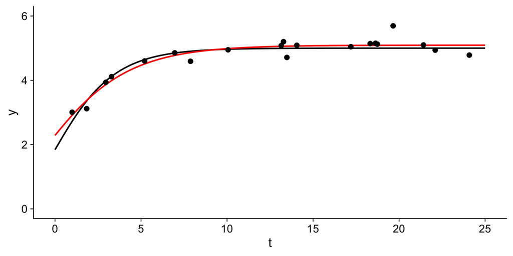

## References

Goldberg, D. E. 1989. *Genetic Algorithms in Search, Optimization, and Machine Learning*. Addison-Wesley.

Holland, J. H. 1975. *Adaptation in Natural and Artificial Systems: An Introductory Analysis with Applications to Biology, Control, and Artificial Intelligence*. University of Michigan Press.

Mebane, W., Jr., and J. Sekhon. 2011. [Genetic Optimization Using Derivatives: The Rgenoud Package for R](https://doi.org/10.18637/jss.v042.i11). *Journal of Statistical Software* 42:1–26.

Scrucca, L. 2013. [GA: A Package for Genetic Algorithms in R](https://doi.org/10.18637/jss.v053.i04). *Journal of Statistical Software, Articles* 53:1–37.

Scrucca, L. 2017. [On Some Extensions to GA Package: Hybrid Optimisation, Parallelisation and Islands Evolution](https://doi.org/10.32614/rj-2017-008). *R Journal* 9:187. The R Foundation.

Sekhon, J. S., and W. R. Mebane. 1998. [Genetic Optimization Using Derivatives](https://doi.org/10.1093/pan/7.1.187). *Polit. Anal.* 7:187–210.